# Mall Customer Spending Analysis

Jose Gattison

## Overview

This analysis explores mall customer spending behavior, using variables such as age, gender, and annual income to uncover insights that can guide business strategies. By examining customer demographics and income patterns, we aim to improve targeted marketing, product segmentation, and customer engagement strategies.

This is a hypothetical analysis of mall customer data, but it demonstrates how similar data could be used to optimize mall sales performance and customer satisfaction.

## 1. Data Loading and Preprocessing

```r
# Load required libraries
library(readxl)
library(DataExplorer)
library(caTools)
library(rpart)
library(rpart.plot)
library(dplyr)
library(caret)
library(Boruta)
library(cvms)
library(ggplot2)

# Load data
data <- read.csv('Mall_Customers.csv')

# Convert Gender to Factor
data$Gender <- as.factor(data$Gender)
```

## 2. Exploratory Data Analysis (EDA)

### 2.1 Age Distribution

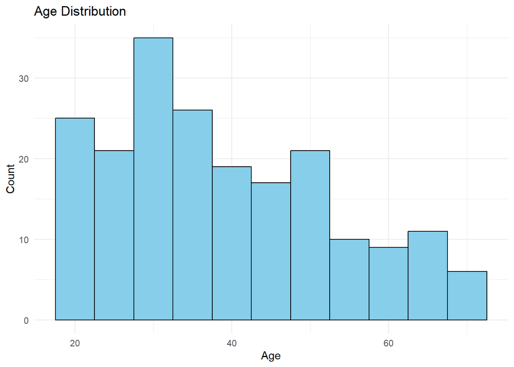

```r
# Age Distribution Plot
ggplot(data, aes(x = Age)) +
  geom_histogram(binwidth = 5, color = "black", fill = "skyblue") +
  labs(title = "Age Distribution", x = "Age", y = "Count") +
  theme_minimal()
```

### 2.2 Annual Income Distribution

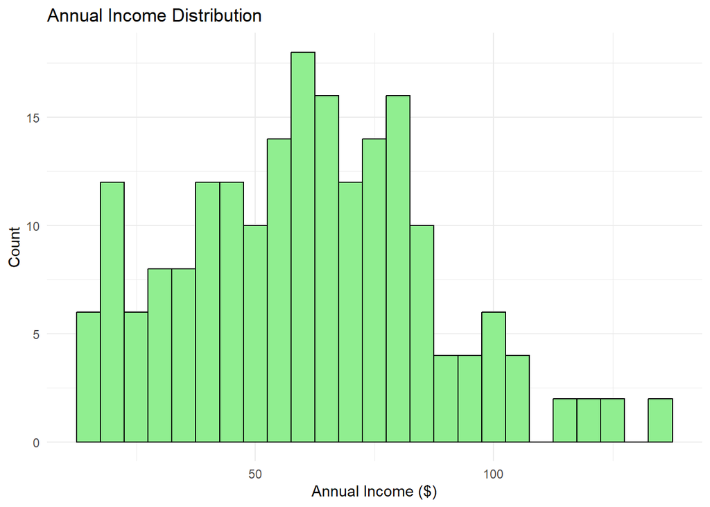

```r
# Annual Income Distribution Plot
ggplot(data, aes(x = Annual.Income)) +
  geom_histogram(binwidth = 5, color = "black", fill = "lightgreen") +
  labs(title = "Annual Income Distribution", x = "Annual Income ($)", y = "Count") +
  theme_minimal()
```

### 2.3 Spending Score Distribution

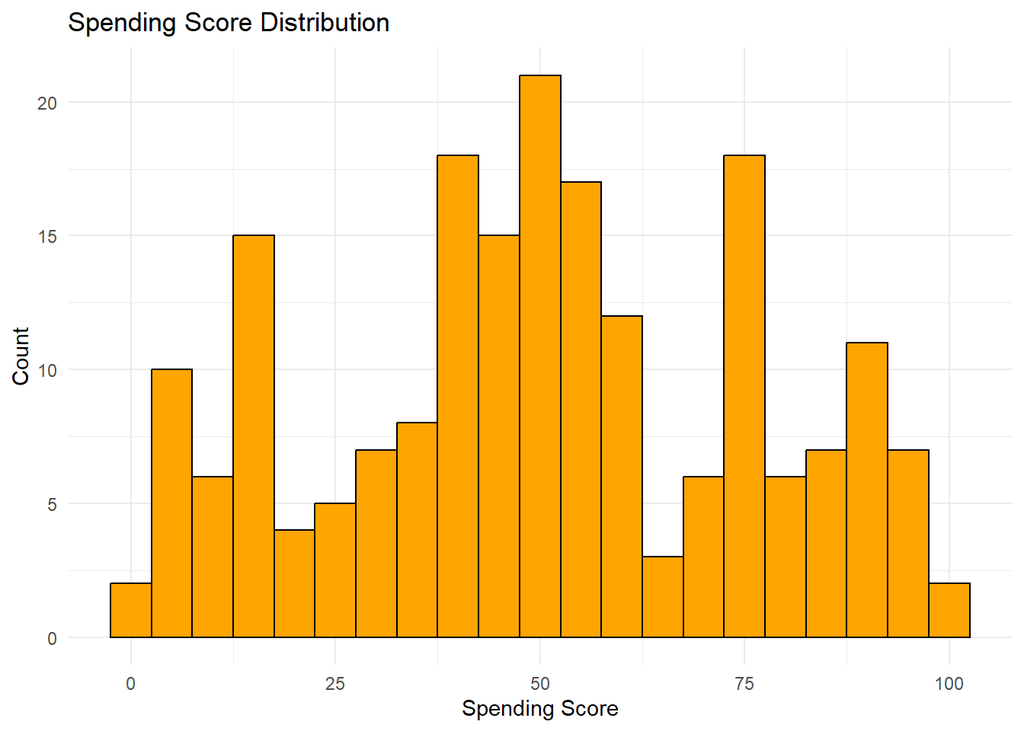

```r
ggplot(data, aes(x = Spending.Score)) +
  geom_histogram(binwidth = 5, color = "black", fill = "orange") +
  labs(title = "Spending Score Distribution", x = "Spending Score", y = "Count") +
  theme_minimal()
```

### 2.4 Gender Distribution

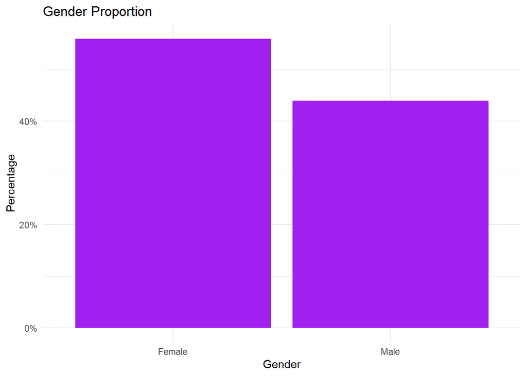

```r
ggplot(data, aes(x = Gender)) +
  geom_bar(aes(y = (..count..)/sum(..count..)), fill = "purple") +
  scale_y_continuous(labels = scales::percent) +
  labs(title = "Gender Proportion", x = "Gender", y = "Percentage") +
  theme_minimal()
```

```r
prop.table(table(data$Gender))
```

```
##
## Female   Male
##   0.56   0.44
```

## 3. Data Relationships

### 3.1 Age vs Annual Income

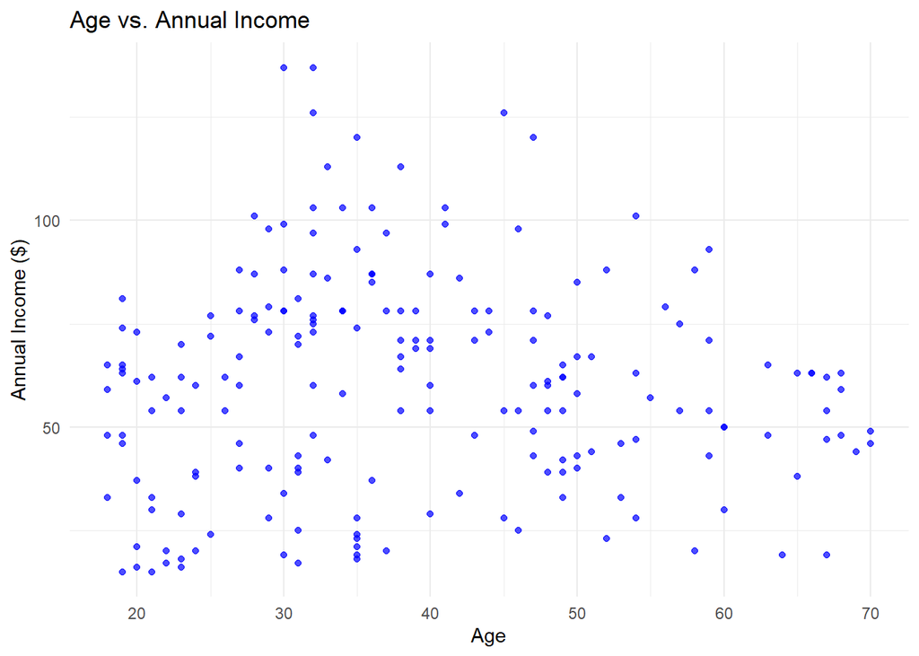

```r
ggplot(data, aes(x = Age, y = Annual.Income)) +
  geom_point(color = "blue", alpha = 0.7) +
  labs(title = "Age vs. Annual Income", x = "Age", y = "Annual Income ($)") +
  theme_minimal()
```

### 3.2 Age vs Spending Score

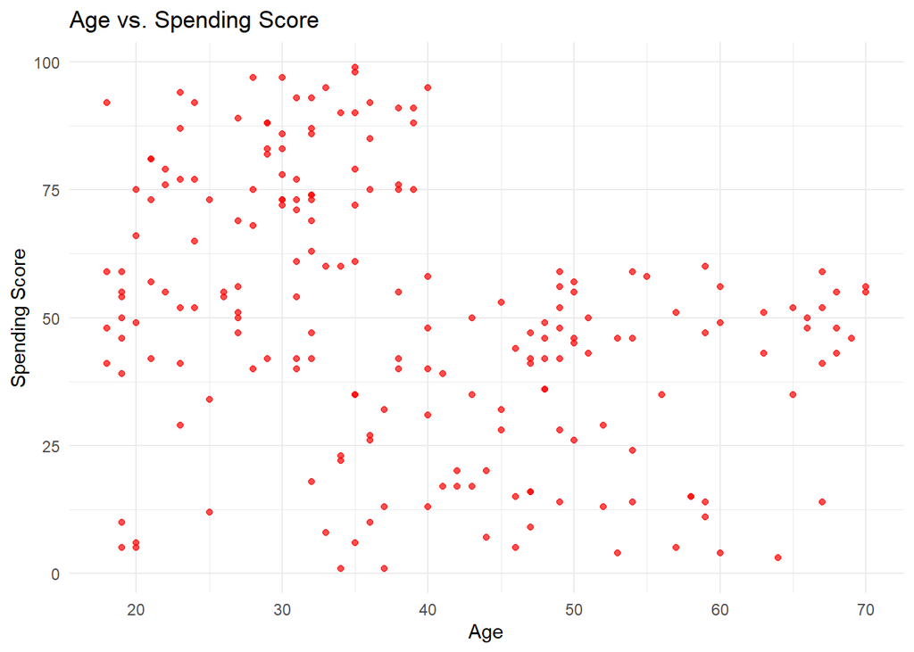

```r
ggplot(data, aes(x = Age, y = Spending.Score)) +
  geom_point(color = "red", alpha = 0.7) +
  labs(title = "Age vs. Spending Score", x = "Age", y = "Spending Score") +
  theme_minimal()
```

### 3.3 Annual Income vs Spending Score

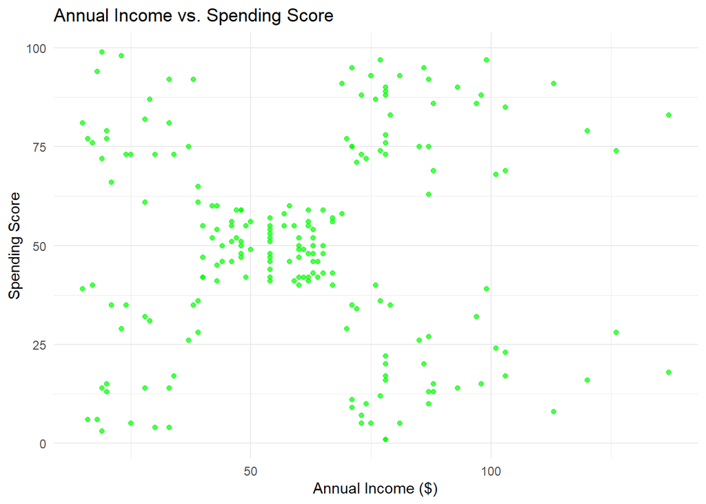

```r
ggplot(data, aes(x = Annual.Income, y = Spending.Score)) +
  geom_point(color = "green", alpha = 0.7) +
  labs(title = "Annual Income vs. Spending Score", x = "Annual Income ($)", y = "Spending Score") +
  theme_minimal()
```

### 3.4 Age by Gender

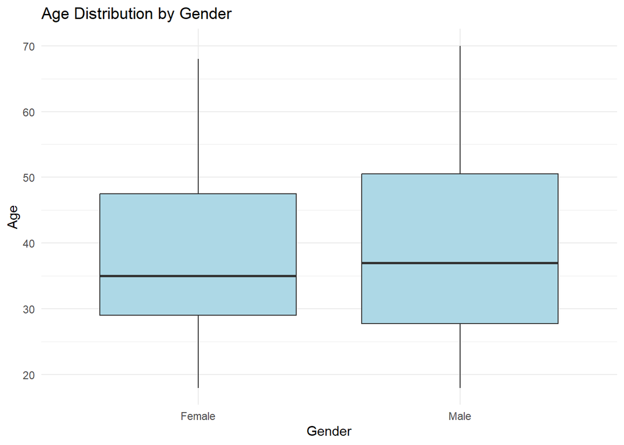

```r
ggplot(data, aes(x = Gender, y = Age)) +
  geom_boxplot(fill = "lightblue") +
  labs(title = "Age Distribution by Gender", x = "Gender", y = "Age") +
  theme_minimal()
```

### 3.5 Annual Income by Gender

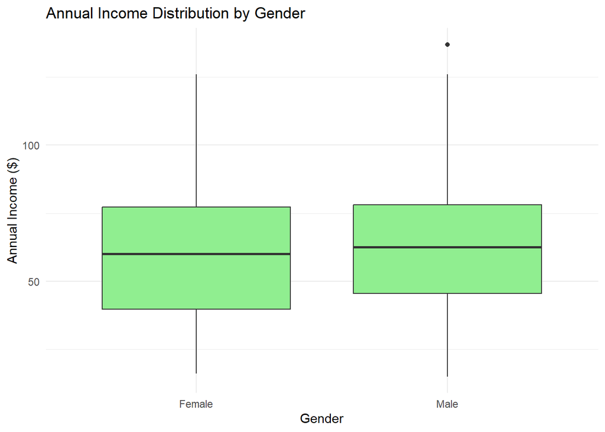

```r
ggplot(data, aes(x = Gender, y = Annual.Income)) +
  geom_boxplot(fill = "lightgreen") +
  labs(title = "Annual Income Distribution by Gender", x = "Gender", y = "Annual Income ($)") +
  theme_minimal()
```

### 3.6 Spending Score by Gender

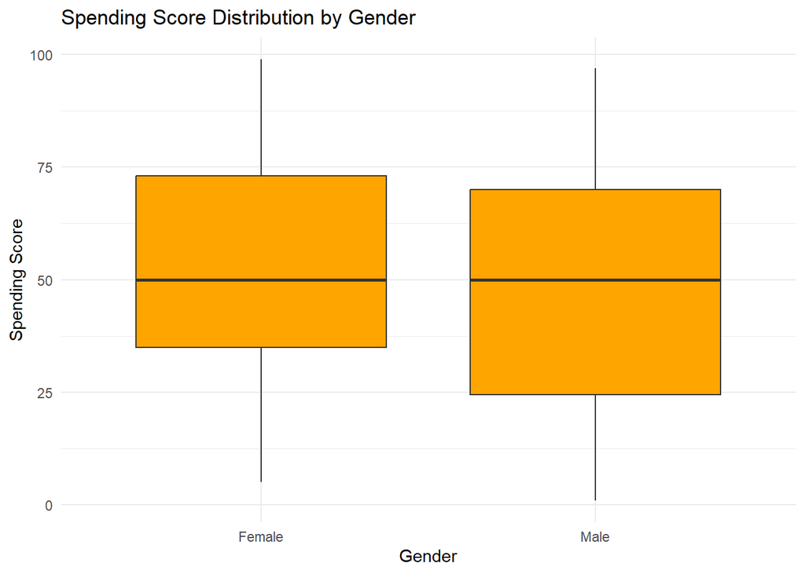

```r
ggplot(data, aes(x = Gender, y = Spending.Score)) +
  geom_boxplot(fill = "orange") +
  labs(title = "Spending Score Distribution by Gender", x = "Gender", y = "Spending Score") +
  theme_minimal()
```

## 4. Decision Tree Analysis: Predicting Spending Behavior

### 4.1 Decision Tree for Spending Score Prediction

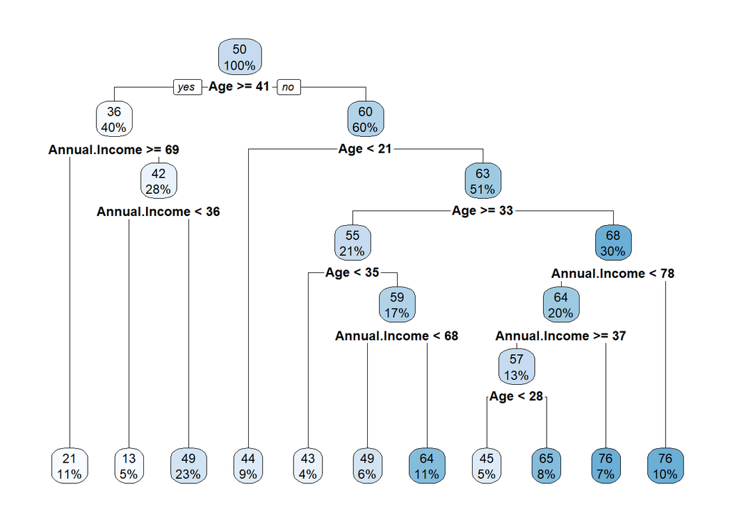

```r
# Splitting the dataset into the Training set and Test set
# install.packages('caTools')
set.seed(123)
split = sample.split(data$Spending.Score, SplitRatio = 0.75)
training_set = subset(data, split == TRUE)
test_set = subset(data, split == FALSE)

# Fitting Kernel SVM to the Training set
model <- rpart(Spending.Score ~ Gender + Age + Annual.Income, data = training_set, method = 'anova')

rpart.plot(model)
```

```r
# Print and visualize the tree to check for overused variables
printcp(model)
```

```
##
## Regression tree:
## rpart(formula = Spending.Score ~ Gender + Age + Annual.Income,
##     data = training_set, method = "anova")
##
## Variables actually used in tree construction:
## [1] Age           Annual.Income
##
## Root node error: 119136/169 = 704.95
##
## n= 169
##
##         CP nsplit rel error  xerror     xstd
## 1 0.193908      0   1.00000 1.01190 0.080371
## 2 0.063523      1   0.80609 0.89079 0.087861
## 3 0.038547      3   0.67905 0.86295 0.103396
## 4 0.026689      4   0.64050 0.80138 0.096850
## 5 0.019162      5   0.61381 0.84729 0.110896
## 6 0.017401      7   0.57548 0.90674 0.125741
## 7 0.011980      8   0.55808 0.90747 0.126673
## 8 0.011485      9   0.54610 0.91506 0.127238
## 9 0.010000     10   0.53462 0.92415 0.127797
```

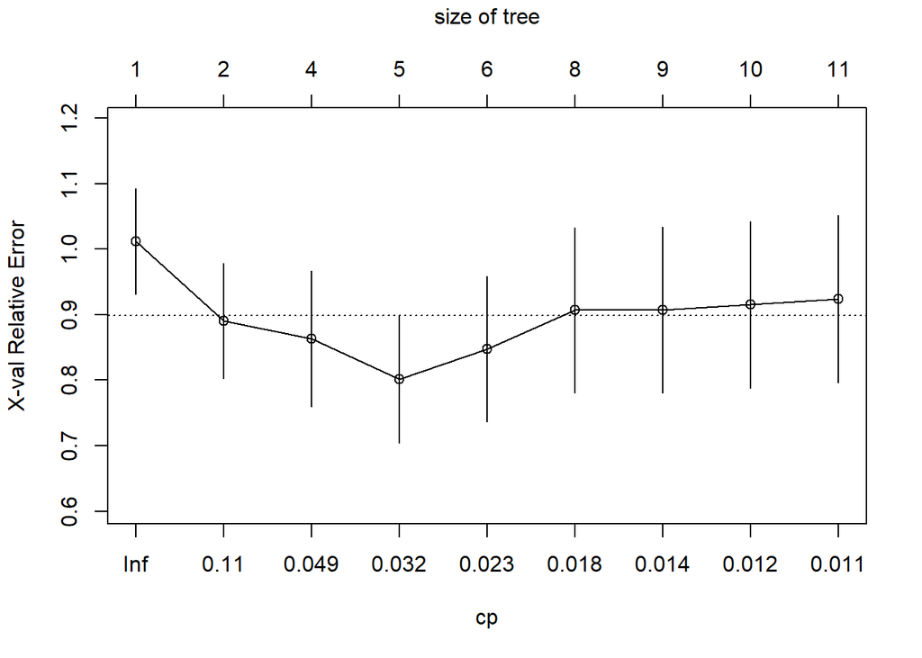

```r
plotcp(model)
```

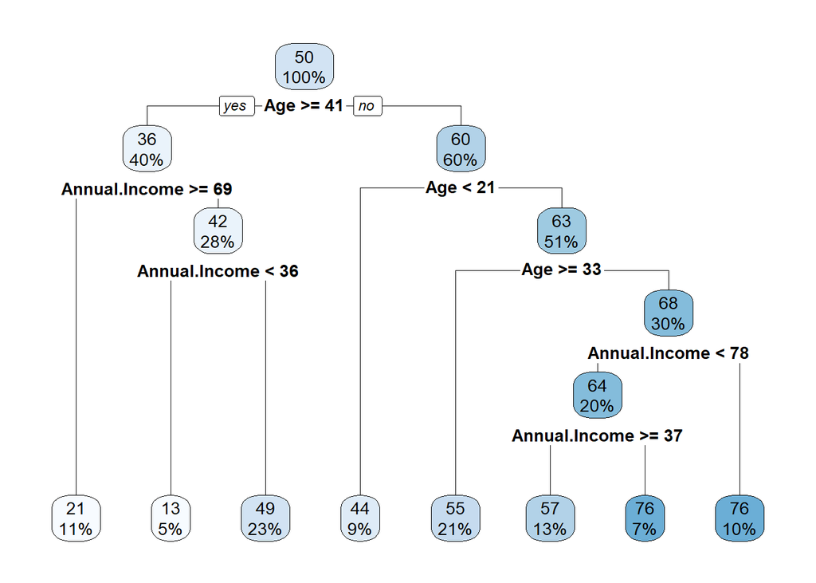

```r
# Prune the tree based on complexity parameter (cp)
pruned_tree <- prune(model, cp = 0.019162)

rpart.plot(pruned_tree)
```